# Лабораторная работа №8

Управление событиями

Перфилов Александр Константинович | Группа НПИбд-03-24

Российский университет дружбы народов, Москва, Россия

24 октября 2025

# Информация

## Докладчик

- Перфилов Александр Константинович
- Группа НПИбд-03-24
- Российский университет дружбы народов
- https://github.com/AlexanderPErfilovKonstantinivich?tab=repositories

## Цель работы

Целью данной работы является получение навыков работы с планировщиками событий cron и at.

## Задание

1. Выполните задания по планированию задач с помощью crond (см. раздел 8.4.1).
2. Выполните задания по планированию задач с помощью atd (см. раздел 8.4.2).

# Выполнение лабораторной работы

## Планирование задач с помощью cron

Запустим терминал и получим полномочия администратора: su -. Просмотрим статус демона crond: systemctl status crond -l и содержимое файла конфигурации /etc/crontab: cat /etc/crontab (рис. 1).

## Планирование задач с помощью cron

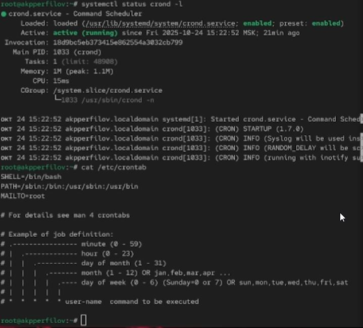

Запуск терминала и получение полномочий администратора, просмотр статуса демона crond и содержимого файла конфигурации /etc/crontab.

## Планирование задач с помощью cron

Теперь просмотрим список заданий в расписании: crontab -l. Ничего не отобразилось, так как расписание ещё не задано. Далее откроем файл расписания на редактирование: crontab -e (рис. 2).

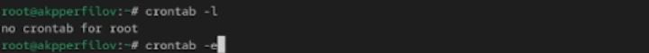

Просмотр списка заданий в расписании, открытие файла расписания на редактирование.

## Планирование задач с помощью cron

Предыдущая команда запустила интерфейс редактора (по умолчанию используется vi). Добавим следующую строку в файл расписания (запись сообщения в системный журнал), используя Ins для перехода в vi в режим ввода: */1* * * * logger This message is written from root cron. Закроем сеанс редактирования vi и сохраним изменения, используя команду vi: Esc : wq. (рис. 3).

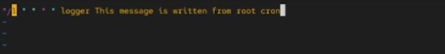

Открытие текстового редактора vi и добавление строки в файл расписания.

## Планирование задач с помощью cron

Просмотрим список заданий в расписании: crontab -l (в расписании появилась запись о запланированном событии). Не выключая систему, через некоторое время (2–3 минуты) просмотрим журнал системных событий: grep written /var/log/messages (рис. 4).

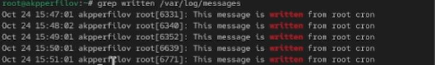

Просмотр списка заданий в расписании, просмотр журнала системных событий.

## Планирование задач с помощью cron

Вернёмся в текстовый редактор vi и изменим запись в расписании crontab на следующую: 0 */1* * 1-5 logger This message is written from root cron (рис. 5).

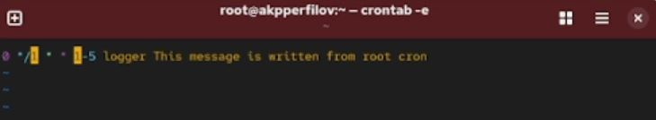

Изменение записи в расписании crontab.

## Планирование задач с помощью cron

Теперь просмотрим список заданий в расписании: crontab -l (рис. 6).

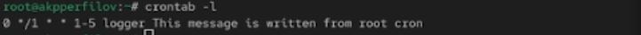

Просмотр списка заданий в расписании.

## Планирование задач с помощью cron

Перейдём в каталог /etc/cron.hourly и создадим в нём файл сценария с именем eachhour (рис. 7).

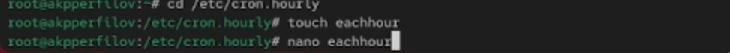

Открытие каталога /etc/cron.hourly и создание в нём файла сценария с именем eachhour.

## Планирование задач с помощью cron

Далее откроем файл eachhour для редактирования и пропишем в нём следующий скрипт (запись сообщения в системный журнал) (рис. 8).

## Планирование задач с помощью cron

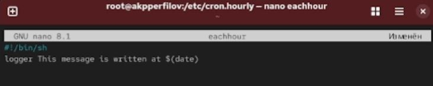

Открытие файла eachhour для редактирования и прописывание в нём скрипта.

## Планирование задач с помощью cron

Сделаем файл сценария eachhour исполняемым. Теперь перейдём в каталог /etc/crond.d и создадим в нём файл с расписанием eachhour (рис. 9).

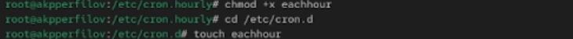

Делаем файл сценария eachhour исполняемым, открытие каталога /etc/crond.d и создание в нём файла с расписанием eachhour, открытие файла на редактирование.

## Планирование задач с помощью cron

Откроем этот файл для редактирования и поместим в него следующее содержимое (рис. 10).

## Планирование задач с помощью cron

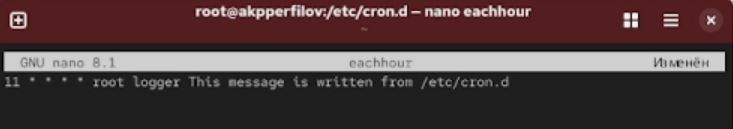

Добавление содержимого в файл и сохранение изменений.

## Планирование задач с помощью cron

Не выключая систему, через некоторое время (2 часа) просмотрим журнал системных событий. По журналу видим, что запуск сценария eachhour в соответствии с заданным расписанием был осуществлён (рис. 11).

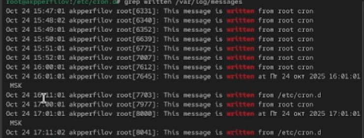

Просмотр журнала системных событий через 2 часа.

## Планирование заданий с помощью at

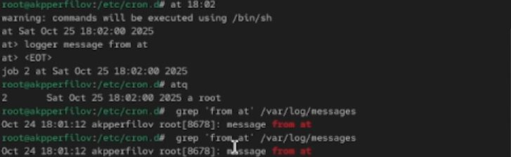

## Выводы

В ходе выполнения лабораторной работы были получены навыки работы с планировщиками событий cron и at.